# Basic statistics

Nambeom Kim

# 기초통계학

## 자료의 종류

### 연속형 자료

- 등간척도 (Interval): 절대값 0이 존재하지 않음, 곱셈법칙 적용이 안됨, 예)온도
- 비율척도 (Ratio): 절대값 0이 존재, 예) 키, 몸무게, 혈압

### 범주형 자료

- 명목척도 (Nominal): 속성을 분류하는 척도, 속성간 순위가 없음, 예) 남/녀, 국어/영어/수학
- 순서척도 (Ordinal): 속성간에 순위개념이 존재하는 척도, 예) 상/중/하, 좋음/보통/나쁨

### 확률변수의 종류표

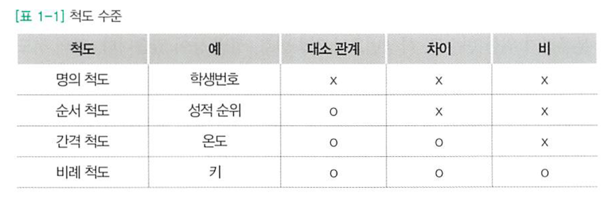

누구나 파이썬 통계분석

## 자료의 축약

### 모집단과 표본집단

- 모집단: 이해하고자 하는 집단전체, 예)우리나라 고등학생 평균키, 고혈압환자
- 표본집단 : 모집단에서 추출된 집단, 예) 추출된 고등학생 100명, 연구에 참여한 고혈압 환자 50명

## 범주형 자료의 요약

- k x c 분할표 (Contigency table)
- 막대그래프 (Barplot)
- 파이 차트 (Pie chart)

```
 4  6  8
11  7 14
```

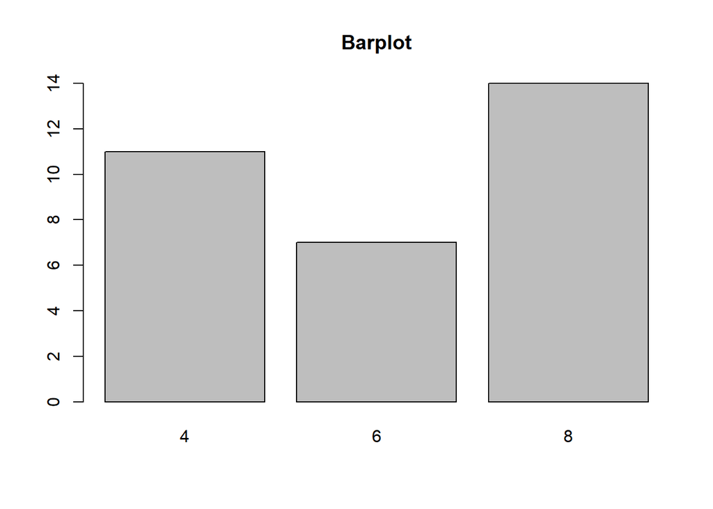

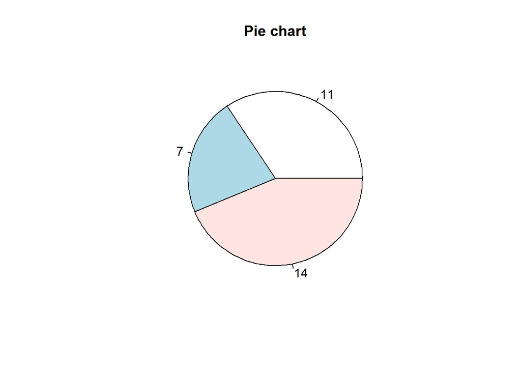

## 연속형 자료의 요약

- 돗수분포표 (Frequency table)
  - 각 범주에 속하는 관측값의 갯수를 그 범주의 돗수라고 함
  - 이 돗수를 전체 자료의 갯수로 나눈 값을 상대돗수라고 함
  - 각 범주에 대응되는 돗수 와 상대돗수를 나타낸 표

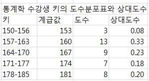

- 히스토그램 (Histogram)
- 상자수염 그림 (Boxplot)
- 바이올린 그림 (Violin plot)

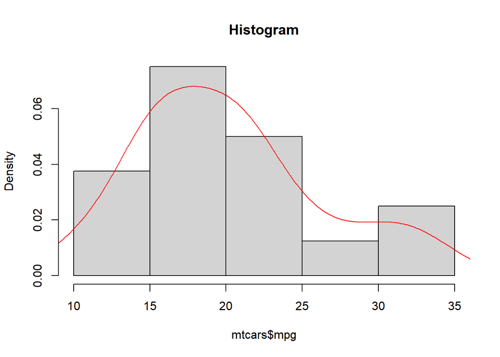

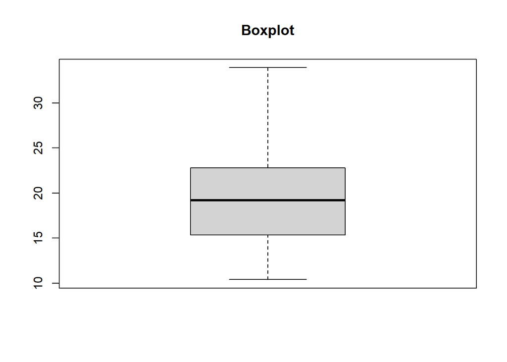

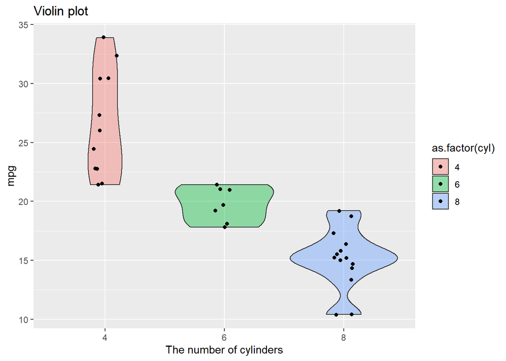

## 그래프를 통한 자료의 요약의 장단점

- 장점: 자료를 한 눈에 알아볼 수 있음
- 단점: 그림의 모양이 작성자의 주관적 판단에 따라 달라질 수 있음

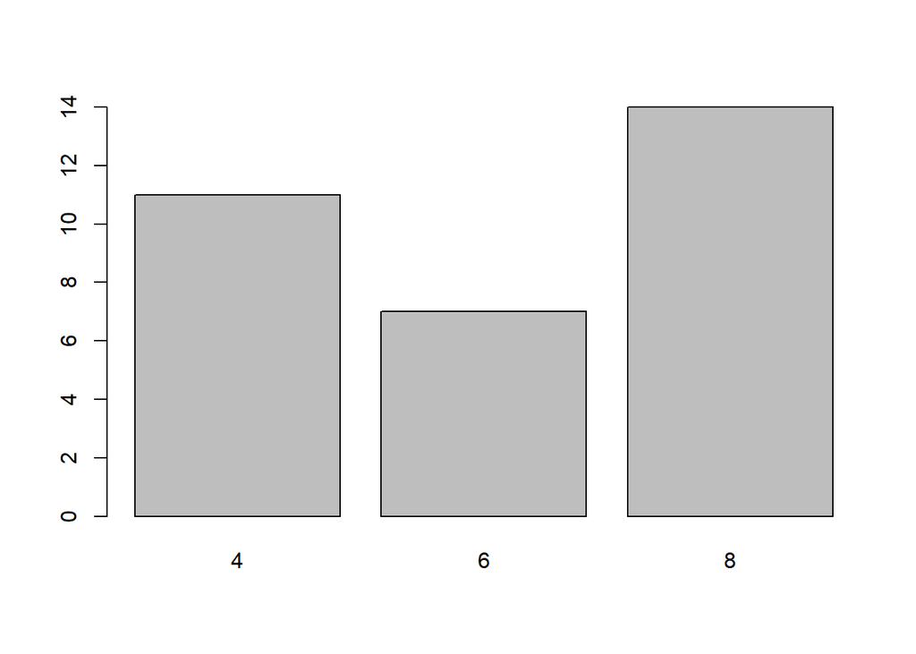

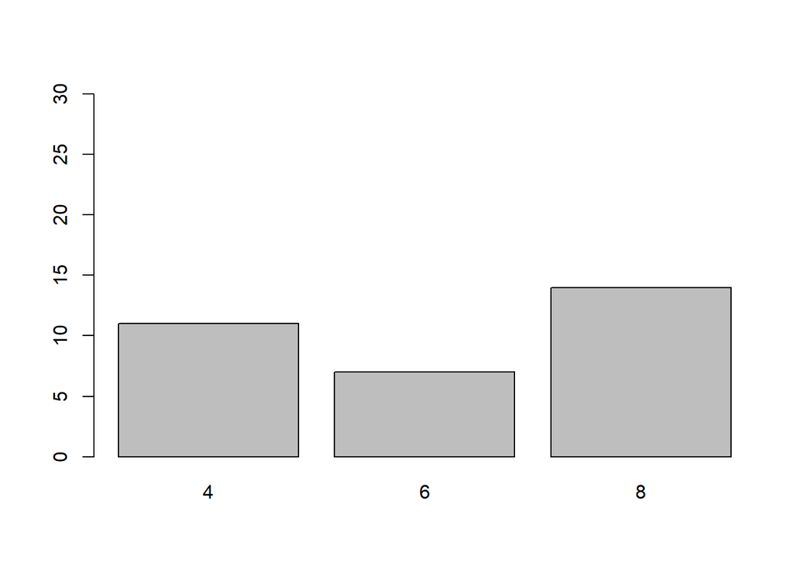

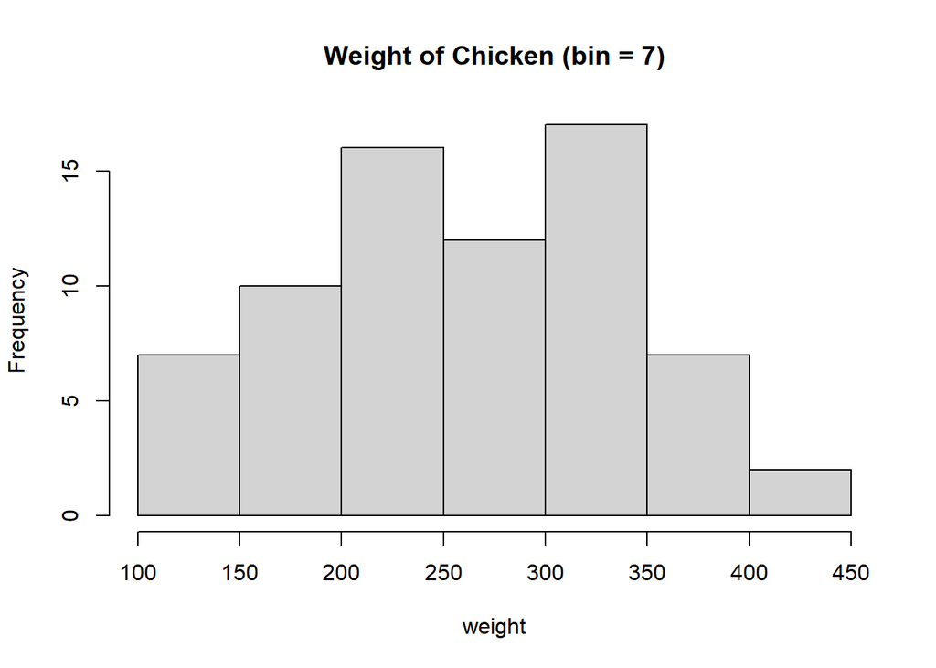

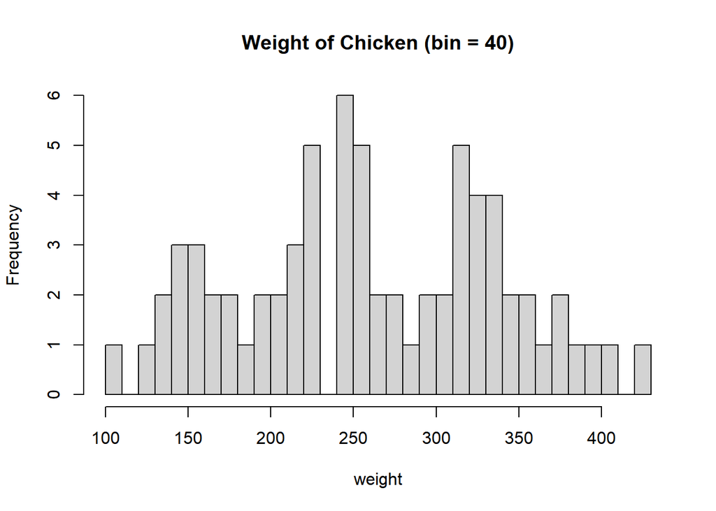

## 수치를 통한 연속형 자료의 요약

### 예제

```
# A tibble: 5 x 2
  value     n
  <dbl> <int>
1     3     1
2     5     2
3     8     1
4     9     1
5    10     1
```

```
[1] "mean of value=  6.67"
```

```
[1] "median of value=  6.5"
```

## 표본평균, 중앙값, 최빈값의 비교

- 표본평균은 이해하기 쉽고 이론적 전개가 용이
- 표본평균은 전체 관측치를 반영하지만 이상치 (Outlier)에 영향을 받음
- 중앙값 중앙 부분의 관측치에 영향을 받고 이상치 (Outlier)에 영향을 받지 않음
- 이상치 들이 있는 경우 표본평균과 중앙값을 적절히 사용

### 어느 보험회사 직원 7명의 한달 수입은 다음과 같다

- 수입의 평균과 중앙값을 구하여라
- 두 개의 값 중에서 어느 것이 중심위치를 측정하기에 적당한가?

```
# A tibble: 7 x 1
  value
  <dbl>
1   950
2   775
3   925
4  2500
5  1150
6   850
7   975
```

```
[1] "mean of value =  1160.71"
```

```
[1] "median of value =  950"
```

## 퍼짐의 정도

### 분산과 표준편차 (Variance and Standard deviation, SD)

- 자료가 중심으로 부터 얼마나 퍼져있는 지를 표현 수치
- $S^2 = \frac{\sum_i^N (X_{i}-\overline{X})^2}{N-1}$
- sd = $\sqrt{S^2} = S$
- 범위(Range): 최댓값 - 최솟값
- 사분위수범위(InterQuartile Range, IQR): 3사분위수 - 1사분위수

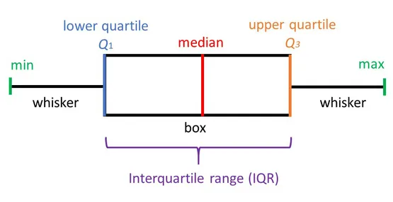

https://www.simplypsychology.org/boxplots.html

- 표본분산, 표본표준편차, 범위, 사분위수를 구하여라

```
[1]  2  3  5  7  9 10
```

### 표본편차, 범위, 사분위수범위 비교

- 표준편차는 표본평균과 같은 이론적 배경
- 사분위수 범위는 중앙값과 같은 이론적 배경
- 중심측도로서 표본평균를 사용할 경우 표준편차를 사용
- 중심측도로서 중앙값을 사용할 경우 사분위수 범위를 사용

### 연습문제

```
[1] 20 18 19 18 12 14
```

## 두 변수간의 자료 요약

### 분할표

```
        Transmission
Cylinder  0  1
       4  1 10
       6  3  4
       8 14  0
```

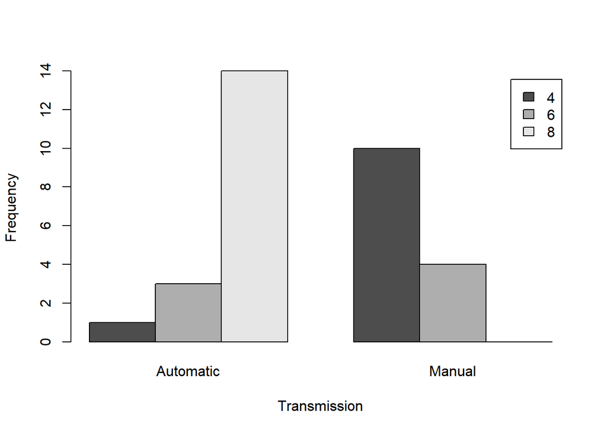

### 상관분석 (Correlation)

- 두 연속형 변수간에 선형적 연관관계가 있는 지를 분석하는 통계적 방법
- 두 연속형 변수간의 연관된 정도를 나타내는 척도이며 인과관계를 설명하는 것은 아님 - 상관계수(Correlation coefficient)는 선형적 관계의 강도를 나타냄
- 모집단 상관계수는 $\rho$, 표본집단의 상관계수는 $r$로 표기

### 그림을 통한 상관관계 요약: 산점도

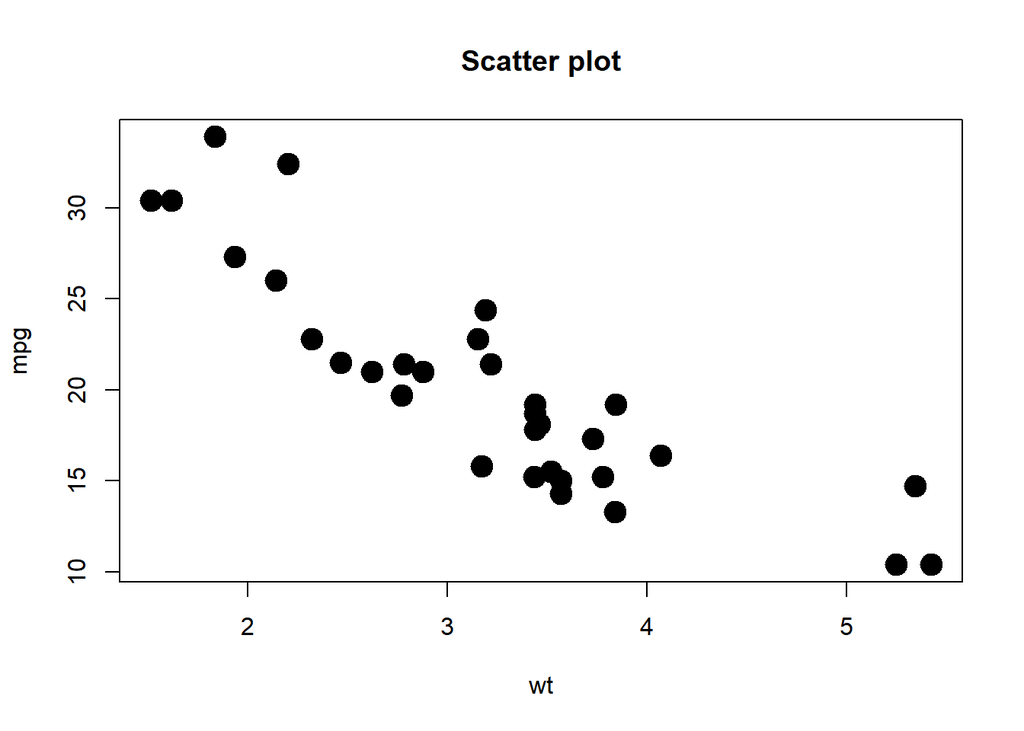

### 피어슨 상관계수 (Pearson’s r)

- 두 연속형 변수가 정규분포를 따르는 경우에 사용함
- r 값이 + 이면 양의 상관관계, - 값이면 음의 상관 관계를 의미
- r 값의 범위는 -1 에서 +1 까지 분포하며 절대값이 1에 가까울 수록 높은 상관성을 의미
- r 값의 해석 (절대적 기준은 아님)
  - 절대값이 0.7 ~ 0.9 : 높은 상관 관계
  - 절대값이 0.4 ~ 0.7 : 중등도 상관 관계

$r_{p} = \frac{Cov(x, y)}{\sqrt{Var(x)}\sqrt{Var(y)}} = \frac{\sum_i^n(X_i-\overline{X})(Y_i-\overline{Y})}{\sqrt{\sum_i^n(X_i-\overline{X})^2}\sqrt{\sum_i^n(Y_i-\overline{Y})^2}}$

$Cov(X, Y) = E(X-u_X)(Y-u_Y) = \frac{\sum_i^n(X_i-\overline{X})(Y_i-\overline{Y})}{n-1}$

### 스피어만 상관계수 (Spearman’s r)

- 두 변수 간에 상관관계를 나타내는 비모수적 방법
- 두 연속형 변수가 정규분포를 따르지 않는 경우에 사용함
- 순서형 자료에서도 적용이 가능
- 비선형적 연관성도 판단할 수 있음
- r 값의 범위는 -1 에서 +1 까지 분포하며 절대값이 1에 가까울 수록 높은 상관성을 의미

$$\large r_{s} = \frac{Cov(x_{(i)}, y_{(i)})}{\sqrt{Var(x_{(i)}}\sqrt{Var(y_{(i)})}}$$

- $x_{(i)}, y_{(i)}$는 x, y의 순위값 (rank)

$$\large r_{s} = 1 - \frac{6\sum d_i^2}{n(n^2-1)}$$

- $d_i = x_{(i)}-y_{(i)}$

### 예, 수학점수와 영어점수와의 관계 등 등

| 수학점수 | 영어점수 |
| --- | --- |
| 88 | 73 |
| 55 | 65 |
| 66 | 70 |
| 62 | 62 |
| 69 | 68 |

### 산점도와 스피어만 상관계수

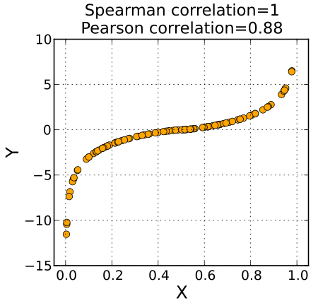

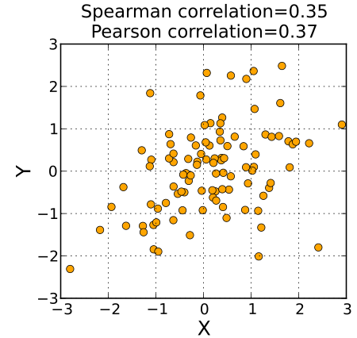

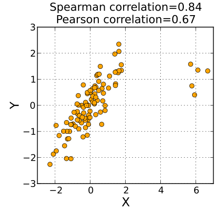

https://ko.wikipedia.org/wiki/%EC%8A%A4%ED%94%BC%EC%96%B4%EB%A7%8C_%EC%83%81%EA%B4%80_%EA%B3%84%EC%88%98

### 문제) 다음 자료 간에 피어슨상관계수를 구하여라

```
  v1 v2
1  5 28
2  3 28
3  5 23
4 10 24
```